# Question

A wrap-around L-shaped patio will measure 26 feet along both walls. The patio will stick out $x$ feet from the walls, and the total area will be 924 square feet. *Note: you can assume all angles are right angles.*

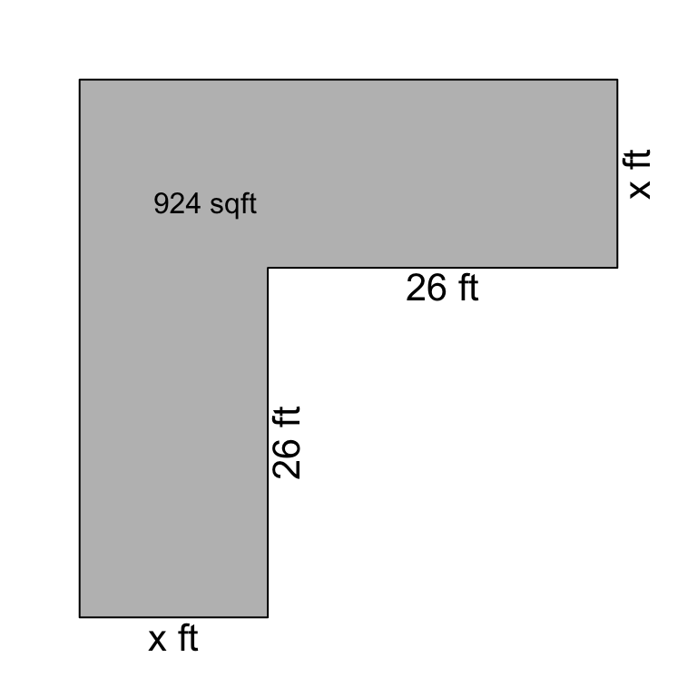

What value of $x$ satisfies the conditions stated above?

# Solution

We can write an equation by saying the sum of $x^2$ and $26x$ and $26x$ equals 924. These expressions represent the areas of a small square and two rectangles.

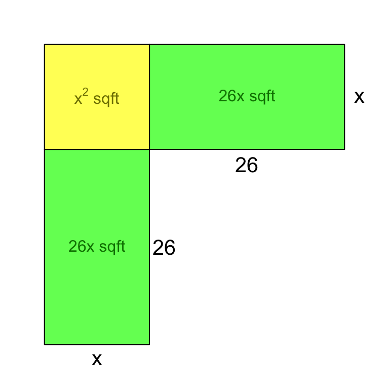

$$x^2+26x+26x~=~924$$

Combine like terms.

$$x^2+52x~=~924$$

There is a fun way to solve this. We will “complete the square”. In this situation, the means we can imagine adding some extra area to the picture to make a large square. In this case, we need to add a square with edge lengths of 26, adding 676 square feet to the area.

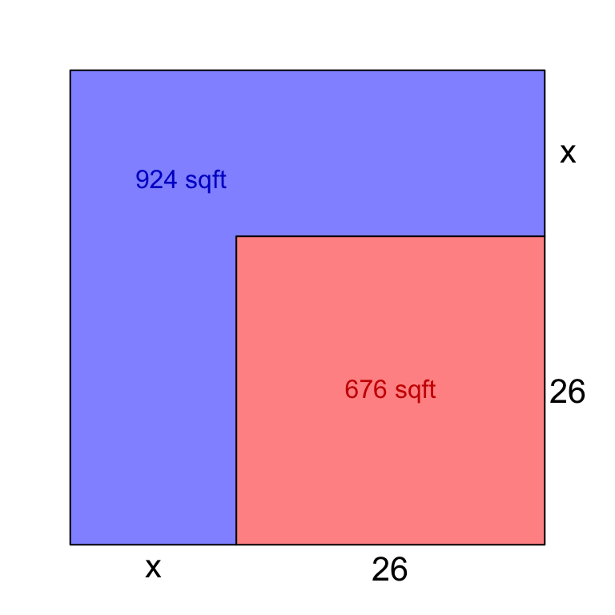

$$x^2+52x+676~=~924+676$$

$$x^2+52x+676~=~1600$$

But, notice, if you look at the last picture, we have another way to represent the total area. The newly formed large square has side lengths of $x+26$. So we can represent the total area of the large square as $(x+26)^2$.

$$(x+26)^2~=~1600$$

We can now use the square-root operation on both sides of the equation.

$$\sqrt{(x+26)^2}~=~\sqrt{1600}$$

$$x+26~=~40$$

And, lastly, subtract 26 from both sides of the equation.

$$x~=~40-26$$

$$x~=~14$$

# Meta-information

extype: num exsolution: 14 exname: complete_the_square_B